# BUS212 6b Automated Data Collection

## Introduction

This code is adapted from the book *AUTOMATED DATA COLLECTION WITH R*, by Simon Munzert, Christian Rubba, Peter Meissner, Dominic Nyhuis. The example comes from Chater 1, and demonstrates how to read in data from a website, prepare it for analysis, and then produce some visualization.

The example uses the Wikipedia page about the *Endangered World Heritage Sites*, which are places in the world that are (a) included in the list of antiquities and natural wonders known as World Heritage Sites and (b) in danger due to natural or political reasons.

The script requirs four packages:

```r
# load packages
library(stringr)
library(XML)
library(maps)
library(RCurl)
```

The relevant website is https://en.wikipedia.org/wiki/List_of_World_Heritage_in_Danger. The first code chunk reads the relevant data into an object called `heritage_parsed` using the command `getURL`.

```r
# parsing from Wikipedia web site
fileURL <- "https://en.wikipedia.org/wiki/List_of_World_Heritage_in_Danger"
xData <- getURL(fileURL)
heritage_parsed <- htmlParse(xData)
```

The heritage_parsed object contains the full list of sites as well as those in danger. The next few lines separate the full table and the table of endangered sites.

```r
tables <- readHTMLTable(heritage_parsed, stringsAsFactors = FALSE)
danger_table <- readHTMLTable(heritage_parsed, stringsAsFactors = FALSE, which = 2) # alternatively: directly select second table
# extract desired table
danger_table <- tables[[2]]
names(danger_table)
```

```
[1] "Name"            "Image"           "Location"
[4] "Criteria"        "Area\nha (acre)" "Year (WHS)"
[7] "Endangered"      "Reason"          "Refs"
```

```r
# select and rename columns
danger_table <- danger_table[,c(1,3,4,6,7)]
colnames(danger_table) <- c("name","locn","crit","yins","yend")
danger_table$name[1:3]
```

```
[1] "Abu Mena"
[2] "Air and Ténéré Natural Reserves"
[3] "Ancient City of Aleppo"
```

In its raw form, the data are not ready for analysis. This chunk performs several steps to clear and reorganize the data. Towards the end of the chunk, notice that it is pulling out longitude and latitudes in order to map the sites.

```r
# cleanse criteria
danger_table$crit <- ifelse(str_detect(danger_table$crit, "Natural")==T, "nat", "cult")
# cleanse years
danger_table$yins <- as.numeric(danger_table$yins)
danger_table$yins
```

```
 [1] 1979 1991 1986 1980 1979 2011 1982 1982 1982 2003
[11] 1994 1996 1986 2012 1983 1993 2006 2003 1998 1979
[21] 1980 1980 1985 2000 1993 2005 1980 2004 1988 2002
[31] 2004 1981 2016 1981 1996 1981 1986 1986 1988 1982
[41] 2007 1982 1985 1981 1984 2007 1978 1980 1988 2004
[51] 2001 2004 1979 2014
```

```r
danger_table$yend
```

```
 [1] "2001-"            "1992-"
 [3] "2013-"            "2013-"
 [5] "2013-"            "2013-"
 [7] "2016-"            "2016-"
 [9] "2016-"            "2003-"
[11] "2010-"            "2009-"
[13] "1986-"            "2012-"
[15] "2003-"            "2005-"
[17] "2013-"            "2003-"
[19] "2013-"            "19932007, 2010-"
[21] "2012-"            "19841992, 1996-"
[23] "2015-"            "2016-"
[25] "2000-"            "2005-"
[27] "1997-"            "2012-"
[29] "1997-"            "2002-"
[31] "2006-"            "1992-"
[33] "2016-"            "2007-"
[35] "1997-"            "1982-"
[37] "2015-"            "2016-"
[39] "2016-"            "2015-"
[41] "2010-"            "19962007, 2011-"
[43] "2016-"            "2004-"
[45] "1999-"            "2007-"
[47] "1996-"            "2013-"
[49] "2012-"            "2012-"
[51] "2010-"            "2011-"
[53] "1994-"            "2014-"
```

```r
yend_clean <- unlist(str_extract_all(danger_table$yend, "^[[:digit:]]{4}"))
danger_table$yend <- as.numeric(yend_clean)
danger_table$locn[c(1,3,5)]
```

```
[1] "EgyAbusir, Egypt30°50'30″N 29°39'50″E / 30.84167°N 29.66389°E / 30.84167; 29.66389 (Abu Mena)"
[2] "Syria !Aleppo Governorate,  Syria36°14'0″N 37°10'0″E / 36.23333°N 37.16667°E / 36.23333; 37.16667 (Ancient City of Aleppo)"
[3] "Syria !Damascus Governorate,  Syria33°30'41″N 36°18'23″E / 33.51139°N 36.30639°E / 33.51139; 36.30639 (Ancient City of Damascus)"
```

```r
# get countries
reg <- "[[:alpha:] ]+(?=[[:digit:]])"
country <- str_extract(danger_table$locn, perl(reg)) # use forward assertion in Perl regular expression
```

```
perl is deprecated. Please use regex() instead
```

```r
head(country)
```

```
[1] "Egypt" "Niger" "Syria" "Syria" "Syria" "Syria"
```

```r
country[29] <- "Côte d'Ivoire / Guinea"
country[32] <- ""
danger_table$country <- country
# get coordinates
reg_y <- "[/][ -]*[[:digit:]]*[.]*[[:digit:]]*[;]"
reg_x <- "[;][ -]*[[:digit:]]*[.]*[[:digit:]]*"
y_coords <- str_extract(danger_table$locn, reg_y)
(y_coords <- as.numeric(str_sub(y_coords, 3, -2)))
```

```
 [1]  30.84167  18.28300  36.23333  32.51806  33.51139
 [6]  36.33417  32.82500  32.63833  32.80528  35.45667
[11]  42.26222  17.31700  -8.11111  31.70444   9.16700
[16]  11.41700  34.78167  34.83194 -11.68306  25.31700
[21]   9.55389   4.00000  35.58806  39.05000  14.20000
[26] -20.20833  -2.50000  53.40667   9.00000  34.39667
[31]  42.66111   7.60000   6.83972  13.00000   2.00000
[36]  31.77667  15.35556  30.13333  13.90639  15.92694
[41] -14.46700  15.74444  24.83333  -8.95778  -2.00000
[46]  34.20000  13.18300  34.55417  16.77333  16.28933
[51]   0.32917  -2.50000   0.91700  31.71972
```

```r
danger_table$y_coords <- y_coords
x_coords <- str_extract(danger_table$locn, reg_x)
(x_coords <- as.numeric(str_sub(x_coords, 3, -1)))
```

```
 [1]  29.6638900   8.0000000  37.1666700  36.4816700
 [5]  36.3063900  36.8441700  21.8583300  14.2930600
 [9]  12.4850000  43.2625000  42.7163900 -87.5330000
[13] -79.0750000  35.2075000  -3.6670000 -69.6670000
[17]  36.2630600  67.8266700 160.1830600 -80.9330000
[21] -79.6558300  29.2500000  42.7183300  66.8333300
[25]  43.3170000 -69.7944400  28.7500000  -2.8444400
[29]  21.5000000  64.5161100  20.2655600  -8.3830000
[33] 158.3308300 -12.6670000  28.5000000  35.2341700
[37]  44.2080600   9.5000000  -4.5550000  48.6266700
[41]  49.7000000 -84.6750000  10.3333300  39.5227800
[45]  21.0000000  43.8670000  38.0670000  38.2666700
[49]  -2.9994400   0.0449111  32.5533300 101.5000000
[53]  29.1670000  35.1305600
```

```r
danger_table$x_coords <- x_coords
danger_table$locn <- NULL
```

With data preparation completed, here is a map of the locations of the endangered sites.

```r
par(oma=c(0,0,0,0))
par(mar=c(0,0,0,0))
pch <- ifelse(danger_table$crit == "nat", 19, 2)
map("world", col = "darkgrey", lwd = .5, mar = c(0.1,0.1,0.1,0.1))
points(danger_table$x_coords, danger_table$y_coords, pch = pch, col = "black", cex = .8)
```

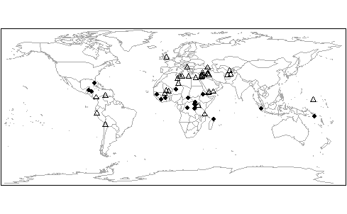

```r
box()
```

Next, the code creates a histogram showing the years in which sites became endangered.

```r
# table heritage criteria
table(danger_table$crit)
```

```
cult  nat
  37   17
```

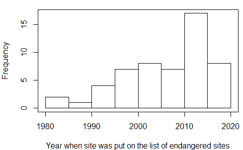

```r
# plot year of endangerment
par(oma=c(0,0,0,0))
par(mar=c(4,4,1,.5))
hist(danger_table$yend, freq=TRUE, xlab="Year when site was put on the list of endangered sites", main="")
box()
```

And finally, a graph showing time between inscription and endangerment.

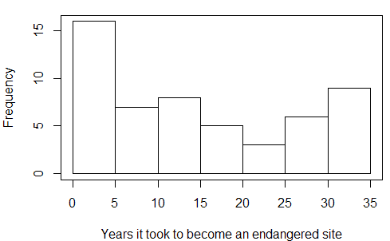

```r
duration <- danger_table$yend - danger_table$yins
par(oma=c(0,0,0,0))
par(mar=c(4,4,1,.5))
hist(duration, freq=TRUE, xlab="Years it took to become an endangered site", main="")
box()
```

[output not shown]